# Ames Housing Project

## Data Cleaning and outliers

```python
import pandas as pd
import numpy as np
import matplotlib.pyplot as plt
from scipy import stats
import seaborn as sns
from sklearn.linear_model import LinearRegression, LassoCV, RidgeCV
from sklearn.preprocessing import PolynomialFeatures, StandardScaler
from sklearn.model_selection import train_test_split, cross_val_score, KFold
from sklearn.metrics import mean_squared_error

%matplotlib inline
```

```python
#Get datasets: NB, test is just read but will not be written over until modelling is done
test = '../datasets/test.csv'
train = '../datasets/train.csv'
```

```python
test = pd.read_csv(test)
train = pd.read_csv(train)
```

```python
#Annotate test and train sets
df = pd.concat([test,train],ignore_index=True,sort=False)
y = df['SalePrice']
```

```python
df.head()
```

|  | Id | PID | MS SubClass | MS Zoning | Lot Frontage | Lot Area | Street | Alley | Lot Shape | Land Contour | ... | Screen Porch | Pool Area | Pool QC | Fence | Misc Feature | Misc Val | Mo Sold | Yr Sold | Sale Type | SalePrice |
| --- | --- | --- | --- | --- | --- | --- | --- | --- | --- | --- | --- | --- | --- | --- | --- | --- | --- | --- | --- | --- | --- |
| 0 | 2658 | 902301120 | 190 | RM | 69.0 | 9142 | Pave | Grvl | Reg | Lvl | ... | 0 | 0 | NaN | NaN | NaN | 0 | 4 | 2006 | WD | NaN |
| 1 | 2718 | 905108090 | 90 | RL | NaN | 9662 | Pave | NaN | IR1 | Lvl | ... | 0 | 0 | NaN | NaN | NaN | 0 | 8 | 2006 | WD | NaN |
| 2 | 2414 | 528218130 | 60 | RL | 58.0 | 17104 | Pave | NaN | IR1 | Lvl | ... | 0 | 0 | NaN | NaN | NaN | 0 | 9 | 2006 | New | NaN |
| 3 | 1989 | 902207150 | 30 | RM | 60.0 | 8520 | Pave | NaN | Reg | Lvl | ... | 0 | 0 | NaN | NaN | NaN | 0 | 7 | 2007 | WD | NaN |
| 4 | 625 | 535105100 | 20 | RL | NaN | 9500 | Pave | NaN | IR1 | Lvl | ... | 185 | 0 | NaN | NaN | NaN | 0 | 7 | 2009 | WD | NaN |

5 rows × 81 columns

```python
# Checking for nulls
df.isnull().sum().sort_values().tail(30)

##no. nulls similar columns might be related.

##From data dictionary, there are columns with NA columns to signify the absence of the additional ammenities
# Pandas dataframe automatically considers all NA columns as NaN, whereas the columns are actually a category by itself
#Need to check and replace all columns that are not in actual fact <blank>/missing
```

```
Street               0
Lot Shape            0
BsmtFin SF 1         1
BsmtFin SF 2         1
Bsmt Unf SF          1
Total Bsmt SF        1
Garage Area          1
Electrical           1
Garage Cars          1
Bsmt Half Bath       2
Bsmt Full Bath       2
Mas Vnr Area        23
Mas Vnr Type        23
Bsmt Qual           80
Bsmt Cond           80
BsmtFin Type 1      80
BsmtFin Type 2      81
Bsmt Exposure       83
Garage Type        157
Garage Finish      159
Garage Yr Blt      159
Garage Cond        159
Garage Qual        159
Lot Frontage       490
SalePrice          879
Fireplace Qu      1422
Fence             2358
Alley             2732
Misc Feature      2824
Pool QC           2917
dtype: int64
```

```python
# If BsmtFin SF 1, SF 2 and total bsmt SF are NaN, total square feet (numeric) should be 0.
df[df['BsmtFin SF 1'].isnull()][['BsmtFin SF 1','Total Bsmt SF', 'BsmtFin SF 2', 'Bsmt Unf SF']]
```

|  | BsmtFin SF 1 | Total Bsmt SF | BsmtFin SF 2 | Bsmt Unf SF |
| --- | --- | --- | --- | --- |
| 2206 | NaN | NaN | NaN | NaN |

```python
df=df.fillna({'BsmtFin SF 1':0, 'Total Bsmt SF': 0, 'BsmtFin SF 2':0,'Bsmt Unf SF':0})
```

```python
# Null in electrical is linked to utilities; check has electricity
df[df['Electrical'].isnull()][['Electrical','Utilities']]
```

|  | Electrical | Utilities |
| --- | --- | --- |
| 635 | NaN | AllPub |

```python
# Most houses with All Pub utilities, electrical holds standard breaker
df[df['Utilities'] == 'AllPub']['Electrical'].value_counts()
```

```
SBrkr    2682
FuseA     185
FuseF      50
FuseP       8
Mix         1
Name: Electrical, dtype: int64
```

```python
# Replace index 635 electrical with SBrkr
df.loc[635,'Electrical'] = 'SBrkr'
```

```python
#column in basment finish type 2 empty but not empty in type 1 check index number
df[df['BsmtFin Type 2'].isnull()]['BsmtFin Type 1'].sort_values(ascending = True).head()
```

```
2026    GLQ
15      NaN
37      NaN
77      NaN
79      NaN
Name: BsmtFin Type 1, dtype: object
```

```python
df.loc[2026,['Bsmt Cond','Bsmt Qual','BsmtFin Type 1','BsmtFin Type 2','Bsmt Exposure']]
```

```
Bsmt Cond          TA
Bsmt Qual          Gd
BsmtFin Type 1    GLQ
BsmtFin Type 2    NaN
Bsmt Exposure      No
Name: 2026, dtype: object
```

```python
# For most cases, when Bsmt cond = TA, quality = Gd, finish type 1 = GLQ
# and bsmt exposure = no, BsmtFin Type 2 is Unf
basement = df[(df['Bsmt Cond'] == 'TA') & (df['Bsmt Qual'] == 'Gd') &\
              (df['BsmtFin Type 1'] == 'GLQ') & \
              (df['Bsmt Exposure'] == 'No')].mode()
basement[['BsmtFin Type 2']].head(2)
```

|  | BsmtFin Type 2 |
| --- | --- |
| 0 | Unf |
| 1 | NaN |

```python
# isnull for Garage type != Garage qual/cond/fin ----> 157 != 159;
# There is a row with garage type = Detchd but no quality, condition, finish and yr Belt
df[df['Garage Qual'].isnull()]['Garage Type'].sort_values(ascending = True).head(3)
```

```
765     Detchd
2591    Detchd
29         NaN
Name: Garage Type, dtype: object
```

```python
# Show mode of Garage Qual, Cond, Finish and Yr Blt when Garage type == Detchd
garage = df[df['Garage Type'] == 'Detchd'].mode()
garage[['Garage Qual','Garage Cond','Garage Finish', 'Garage Yr Blt']].head()
```

|  | Garage Qual | Garage Cond | Garage Finish | Garage Yr Blt |
| --- | --- | --- | --- | --- |
| 0 | TA | TA | Unf | 1950.0 |
| 1 | NaN | NaN | NaN | NaN |
| 2 | NaN | NaN | NaN | NaN |
| 3 | NaN | NaN | NaN | NaN |
| 4 | NaN | NaN | NaN | NaN |

```python
# Unusual data year 2207; to correct to 2007
df['Garage Yr Blt'].sort_values(ascending = False).head(3)
```

```
2578    2207.0
317     2010.0
453     2010.0
Name: Garage Yr Blt, dtype: float64
```

```python
# Correcting year 2207 as 2007
df.loc[2578,'Garage Yr Blt'] = 2007.0
```

```python
#Setting ordinal categories
ordered_shape = ['IR3', 'IR2', 'IR1', 'Reg']
ordered_utilities = ['ELO','NoSeWa','NoSewr','AllPub']
ordered_slope = ['Sev','Mod','Gtl']
ordered_quality = ['None','Po','Fa','TA','Gd','Ex']
ordered_exposure = ['None','No','Mn','Av','Gd']
ordered_bsmt_finish = ['None','Unf','LwQ','Rec','BLQ','ALQ','GLQ']
ordered_electrical = ['Mix','FuseP','FuseF','FuseA','SBrkr']
ordered_functional = ['Sal','Sev','Maj2','Maj1','Mod','Min2','Min1','Typ']
ordered_garage_finish = ['None','Unf','RFn','Fin']
ordered_paved = ['N','P','Y']
ordered_fence = ['None','MnWw','GdWo','MnPrv','GdPrv']
```

```python
#All ordinal columns
ordinal_cols = ['Lot Shape','Utilities','Land Slope','Exter Qual','Exter Cond',
                'Bsmt Qual','Bsmt Cond','Bsmt Exposure','BsmtFin Type 1','BsmtFin Type 2',
                'Heating QC','Electrical','Kitchen Qual','Functional','Fireplace Qu',
               'Garage Finish','Garage Qual','Garage Cond','Paved Drive','Pool QC','Fence']
```

```python
#Changing type to category for ordinal columns and value from data dictionary
df['Lot Shape'] = df['Lot Shape'].astype("category",ordered=True,categories=ordered_shape).cat.codes
df['Utilities'] = df['Utilities'].astype("category",ordered=True,categories=ordered_utilities).cat.codes
df['Land Slope'] = df['Land Slope'].astype("category",ordered=True,categories=ordered_slope).cat.codes
df['Exter Qual'] = df['Exter Qual'].astype("category",ordered=True,categories=ordered_quality).cat.codes
df['Exter Cond'] = df['Exter Cond'].astype("category",ordered=True,categories=ordered_quality).cat.codes
df['Bsmt Qual'] = df['Bsmt Qual'].astype("category",ordered=True,categories=ordered_quality).cat.codes
df['Bsmt Cond'] = df['Bsmt Cond'].astype("category",ordered=True,categories=ordered_quality).cat.codes
df['Bsmt Exposure'] = df['Bsmt Exposure'].astype("category",ordered=True,categories=ordered_exposure).cat.codes
df['BsmtFin Type 1'] = df['BsmtFin Type 1'].astype("category",ordered=True,categories=ordered_bsmt_finish).cat.codes
df['BsmtFin Type 2'] = df['BsmtFin Type 2'].astype("category",ordered=True,categories=ordered_bsmt_finish).cat.codes
df['Heating QC'] = df['Heating QC'].astype("category",ordered=True,categories=ordered_quality).cat.codes
df['Electrical'] = df['Electrical'].astype("category",ordered=True,categories=ordered_electrical).cat.codes
df['Kitchen Qual'] = df['Kitchen Qual'].astype("category",ordered=True,categories=ordered_quality).cat.codes
df['Functional'] = df['Functional'].astype("category",ordered=True,categories=ordered_functional).cat.codes
df['Fireplace Qu'] = df['Fireplace Qu'].astype("category",ordered=True,categories=ordered_quality).cat.codes
df['Garage Finish'] = df['Garage Finish'].astype("category",ordered=True,categories=ordered_garage_finish).cat.codes
df['Garage Qual'] = df['Garage Qual'].astype("category",ordered=True,categories=ordered_quality).cat.codes
df['Garage Cond'] = df['Garage Cond'].astype("category",ordered=True,categories=ordered_quality).cat.codes
df['Paved Drive'] = df['Paved Drive'].astype("category",ordered=True,categories=ordered_paved).cat.codes
df['Pool QC'] = df['Pool QC'].astype("category",ordered=True,categories=ordered_quality).cat.codes
df['Fence'] = df['Fence'].astype("category",ordered=True,categories=ordered_fence).cat.codes
```

```python
# Mapping categories with only 2 unique groups
df['Central Air'] = df['Central Air'].map({'Y':1,'N':0})
df['Street'] = df['Street'].map({'Grvl':1,'Pave':0})
```

```python
#Looking at scatterplots and checking for outliers:
def subplot_scatter(df,list_of_titles, list_of_xlabels):
    ncols = 4
    nrows = int(np.ceil(len(df.columns) / (1.0*ncols)))
    fig, axes = plt.subplots(nrows=nrows, ncols=ncols, figsize=(25, 25))
    counter = 0
    for i in range(nrows):
        for j in range(ncols):
            ax = axes[i][j]
            if counter < len(df.columns):      # Plot when we have data
                ax.scatter(df[df.columns[counter]], y)
                ax.set_xlabel(list_of_xlabels[counter])
                ax.set_title(list_of_titles[counter])
                ax.set_ylabel("Price")
        # Remove axis when we no longer have data
            else:
                ax.set_axis_off()
            counter += 1
    plt.tight_layout()
    plt.show()
```

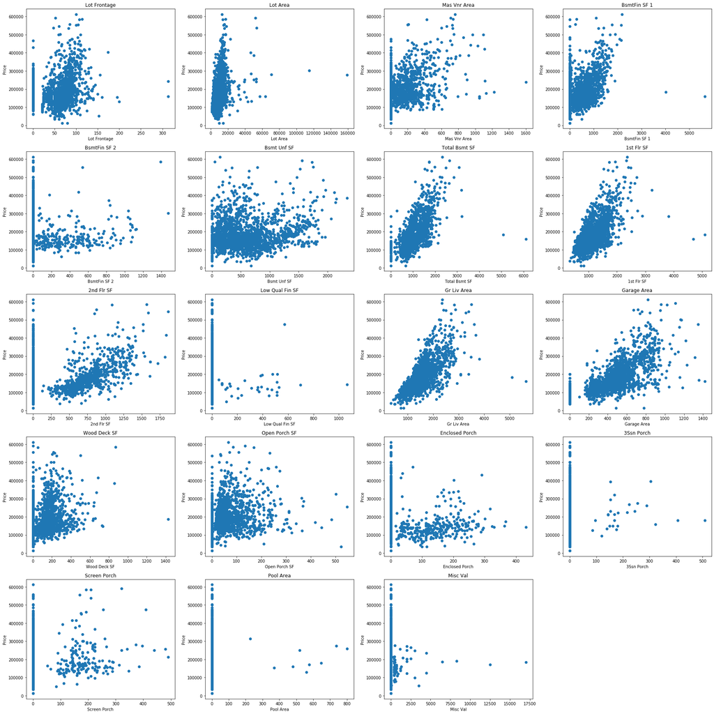

```python
## Look at scatter plots to spot the outliers
subplot_scatter(df[cont_cols],cont_cols,cont_cols)
```

```python
# Following documentation, as seen that there are 5 outliers,
# we will follow suit as seen from the scatter plot in Gr Liv Area.
df[df['Gr Liv Area'] >= 4000].index
```

```
Int64Index([76, 171, 464, 1839, 2764], dtype='int64')
```

```python
# To remove outliers with living area >= 4000 Sq Ft
df.drop(df[df['Gr Liv Area'] >= 4000].index, inplace = True)
```

```python
# Split test and train set again after cleaning
test = df[df['SalePrice'].isnull()]
train = df[df['SalePrice'].notnull()]
```

```python
train.to_csv('../datasets/train_cleaned.csv')
test.to_csv('../datasets/test_cleaned.csv')
```

```python
# Onto manipulation of features
```

## Exploratory Visualizations

```python
# All nominal columns
nom_cols = df.columns[df.dtypes == 'object']
# All continuous columns
cont_cols = ['Lot Frontage','Lot Area','Mas Vnr Area','BsmtFin SF 1','BsmtFin SF 2',
           'Bsmt Unf SF','Total Bsmt SF', '1st Flr SF', '2nd Flr SF',
             'Low Qual Fin SF', 'Gr Liv Area', 'Garage Area','Wood Deck SF',
           'Open Porch SF', 'Enclosed Porch', '3Ssn Porch', 'Screen Porch', 'Pool Area','Misc Val']
# All ordinal columns
ordinal_cols = ['Lot Shape','Utilities','Land Slope','Overall Qual','Overall Cond', 'Exter Qual','Exter Cond',
                'Bsmt Qual','Bsmt Cond','Bsmt Exposure','BsmtFin Type 1','BsmtFin Type 2',
                'Heating QC','Electrical','Kitchen Qual','Functional','Fireplace Qu',
               'Garage Finish','Garage Qual','Garage Cond','Paved Drive','Pool QC','Fence']
# All discrete columns
dist_cols = ['Bsmt Full Bath','Bsmt Half Bath','Full Bath','Half Bath','Bedroom AbvGr', 'Kitchen AbvGr',
             'TotRms AbvGrd','Fireplaces','Garage Cars','Mo Sold','Yr Sold','Street','Central Air']
# All year/time related columns
time_cols = ['Year Built','Year Remod/Add','Garage Yr Blt']
```

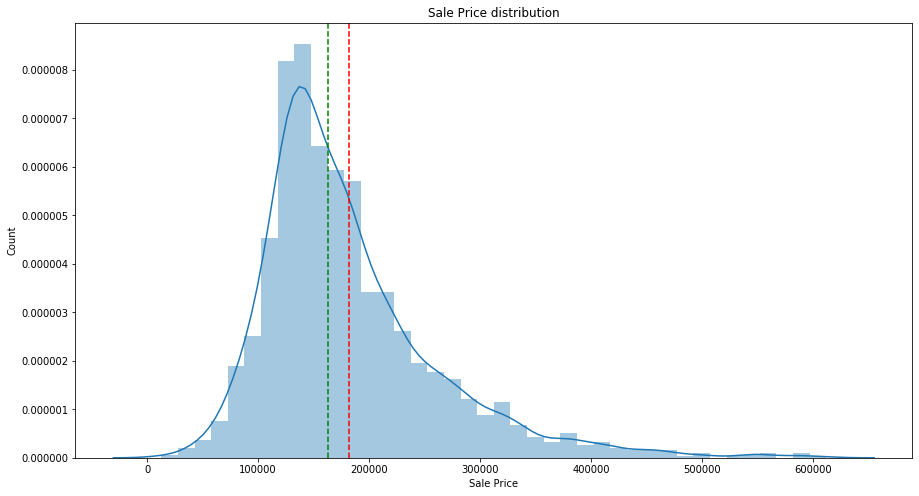

```python
# Look at the distribution of sale prices
fig, axes = plt.subplots(figsize=(15, 8))
sns.distplot(df['SalePrice'], kde=True, bins=40)\
.set(xlabel='Sale Price', ylabel='Count',title="Sale Price distribution");
plt.axvline(df['SalePrice'].mean(), 0,1, ls='--', color = 'red')
plt.axvline(df['SalePrice'].median(), 0,1, ls='--', color = 'green')

plt.show()
```

## Target column distribution

```python
#Looking at scatterplots of continuous columns with sale price
def subplot_scatter(df,list_of_titles, list_of_xlabels):
    ncols = 3
    nrows = int(np.ceil(len(df.columns) / (1.0*ncols)))
    fig, axes = plt.subplots(nrows=nrows, ncols=ncols, figsize=(30, 50))
    counter = 0
    for i in range(nrows):
        for j in range(ncols):
            ax = axes[i][j]
            if counter < len(df.columns):      # Plot when we have data
                ax.scatter(df[df.columns[counter]], y)
                ax.set_xlabel(list_of_xlabels[counter])
                ax.set_title(list_of_titles[counter])
                ax.set_ylabel("Price")
        # Remove axis when we no longer have data
            else:
                ax.set_axis_off()

            counter += 1
    plt.tight_layout()
    plt.show()
```

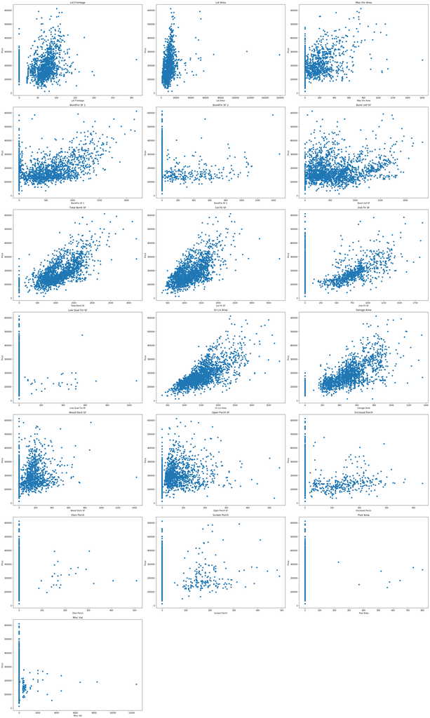

```python
subplot_scatter(df[cont_cols],cont_cols,cont_cols)
```

## Distribution of continuous features against price

However, there are several scatterplots that show how the distributions were heavily skewed towards the lower end of the scale. For example, in the 'Pool Area' columns, we see that most houses do not possess a pool except a handful of a few houses (can be counted; 8). These distributions show that in general, most houses do not possess these miscellaneous features and do not have much effect on the final sale price.

As for the rest of the distributions, we can see that they generally follow a linear, if not slight exponential distribution against sale price. These features will be considered to possess a stronger relationship with the target column.

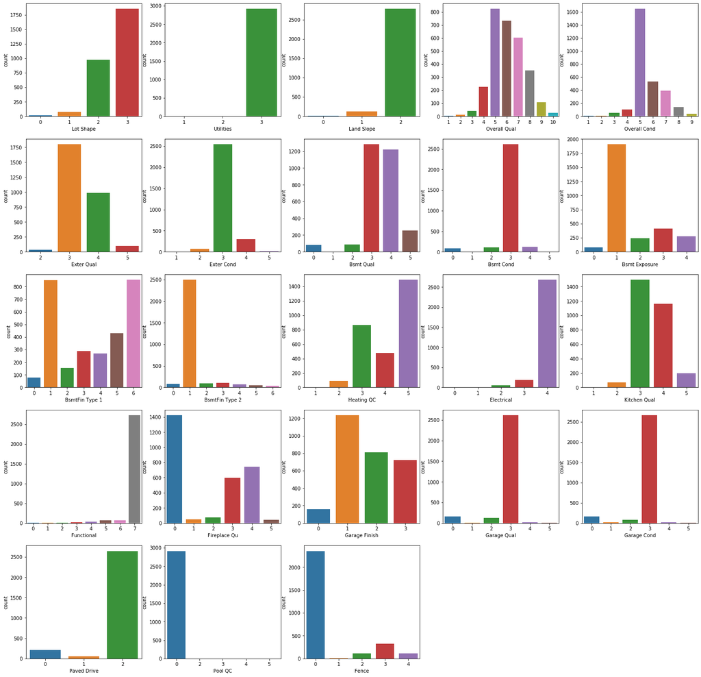

```python
# Plotting the ordinal columns to see their count distribution
fig, ax = plt.subplots(5, 5, figsize=(25, 25))
for variable, subplot in zip(ordinal_cols, ax.flatten()):
    sns.countplot(df[variable], ax=subplot)
ax[4,3].set_axis_off()
ax[4,4].set_axis_off()
```

## Ordinal columns distribution

These distribution plots show us distinctively which level of quality/condition the houses are. In general, the higher the score, the better the house. Thus, skewness will allow us to determine how well the house perform on these houses. Mainly, we see that if scores are concentrated on the left, the quality or score is low; Opposite is true for scores on the right since this is an ordinal feature.

Importantly to note, most ordinal features then to have modes that are highly dominated in one score, for example in Paved Drive, we see that from the data dictionary, we can tell that most houses have a proper paved driveway, and this number greatly overwhelms the partially paved and no pavement subcategory of 1 and 0 respectively.

From an overall perspective, we see that the overall condition and overall quality seems to be normally distributed as it takes into account the average of all these other ordinal features. Thus, it might be more reasonable to forgot the other ordinal scales and to just use the overall ordinal feature for building a model.

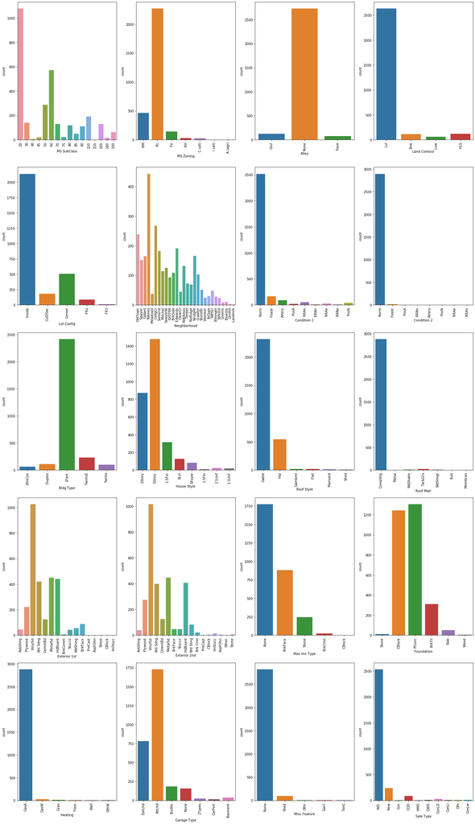

```python
# Plotting the histograms for all norminal columns to see their count distribution
fig, ax = plt.subplots(5, 4, figsize=(25, 45))
for variable, subplot in zip(nom_cols, ax.flatten()):
    sns.countplot(df[variable], ax=subplot)
    for label in subplot.get_xticklabels():
        label.set_rotation(90)
```

## Distribution of nominal columns in counts

As seen from the distributions above, most of the graphs are highly biased towards one sub-category within each category of distribution plot. The lack of variance in theses nominal columns suggest that it is unlikely that these features will impact the target value of sales price. Thus, only categories with enough variance will be selected as features for the model.

In general just to name a few, we can see from glace at these distributions, the most houses sold neighbourhood is NAmes (North Ames), most houses have RL (Residential Low Density) zoning classification, have Regular lot shape, and also have CentralAir.

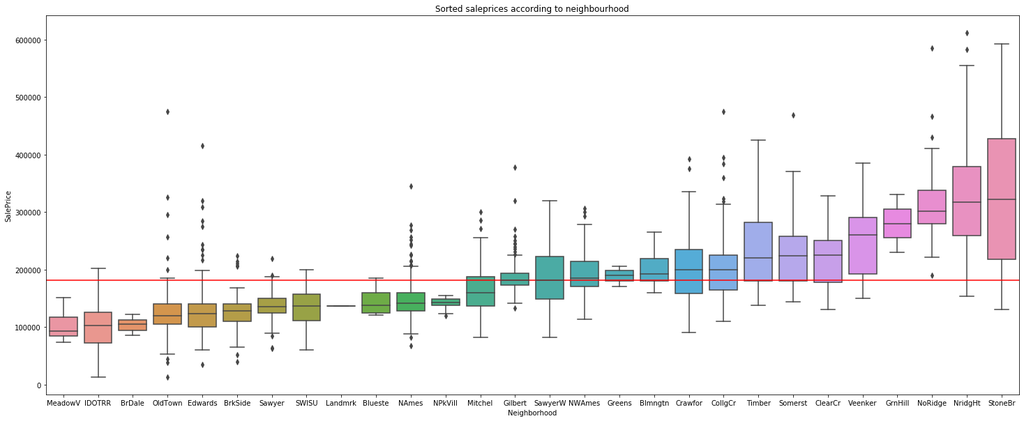

```python
# Looking more indept at neighbourhood with biggest variance between each sub-category
plt.figure(figsize=(25, 10))
sorted_nb = df.groupby(['Neighborhood'])['SalePrice'].median().sort_values()
sns.boxplot(x=df['Neighborhood'], y=df['SalePrice'],
            order=list(sorted_nb.index)).set(title = 'Sorted saleprices according to neighbourhood')
plt.axhline(df['SalePrice'].mean(),linestyle = '-',color = 'red')
plt.show()
```

## Boxplot of neighbourhood against sale price

The red line demarkates the distribution of houses with lower and higher than mean sale prices, and we can see the neighbourhoods that are more expensive or relatively cheaper.

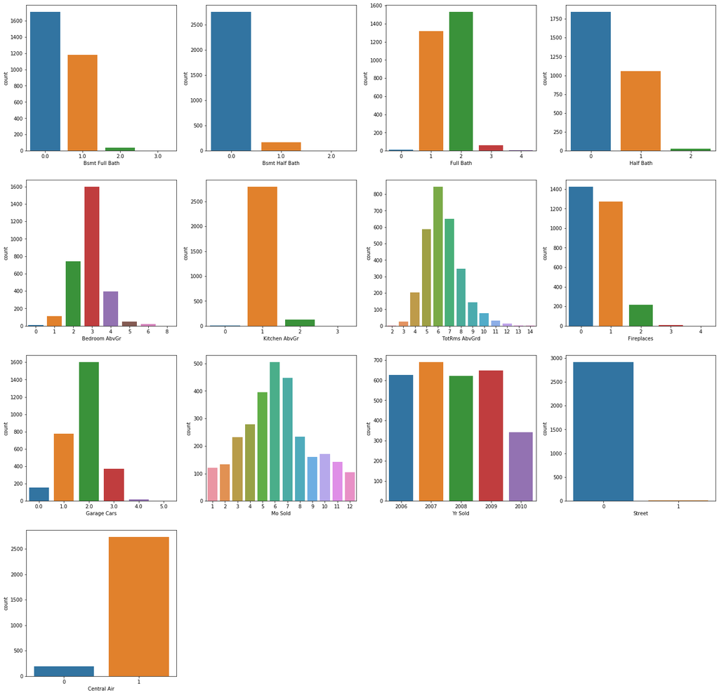

```python
# Plotting the count plots for all discrete columns to see their count distribution
fig, ax = plt.subplots(4, 4, figsize=(25, 25))
for variable, subplot in zip(dist_cols, ax.flatten()):
    sns.countplot(df[variable], ax=subplot)
ax[3,3].set_axis_off()
ax[3,2].set_axis_off()
ax[3,1].set_axis_off()
```

## Distribution of discrete features

A general outlook of these discrete features shows a clear distinct mode for most of them. For example, houses do not have basement bathrooms, have 2 full bathrooms, 2 garage cars, 3 bedrooms, 1 kitchen and 0/1 fireplace. Also, most houses are sold in the month of June.

We can clearly see a dip in sales of houses in 2010, which may be a mis-representation if the data cuts off on the year 2010. Thus, year sold might be a biased feature.

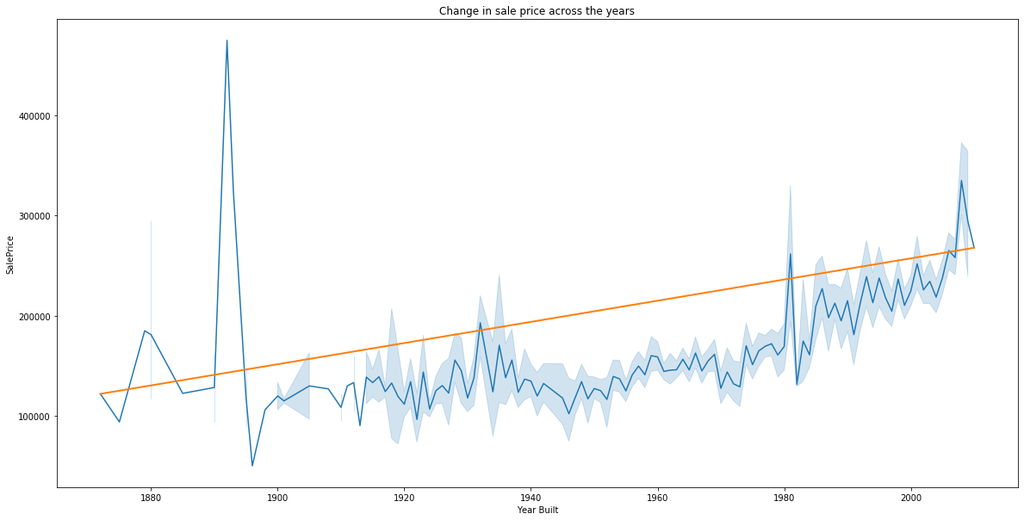

```python
# Look at time sensitive plots
fig, ax = plt.subplots(figsize=(20,10))
sns.lineplot(x = df['Year Built'], y = y).set(title = 'Change in sale price across the years')
plt.plot([1872, 2010], [122000, 267916], linewidth=2)
plt.show()
```

## General trend of across the years of sale prices

Over the years, sale prices has increased of housing has increased. On average from the start of 122k in 1872 to 267k in 2010.

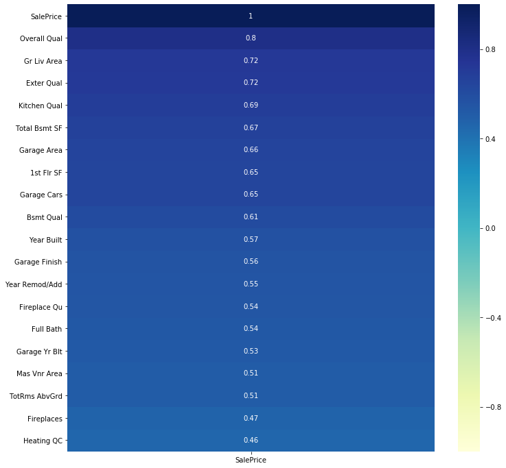

```python
# Several features with top correlation with SalePrice
fig, ax = plt.subplots(figsize=(12,12))
sns.heatmap(df.corr()[['SalePrice']].sort_values('SalePrice').tail(20),
            vmax=1, vmin=-1, cmap='YlGnBu', annot=True, ax=ax);
ax.invert_yaxis()
```

## Feature correlation with target

Some of these features have high correlation to the sale price, and might affect the overall model training if these said features are being used with training of the model. Thus, it is likely that these features are not to be considered during feature engineering. A threshold that might be reasonable would be having the absolute correlation lesser than 0.7.

```python
# Look at high correlations
corr = df.corr().abs()
unstack_corr = corr.unstack()
corr_sort = unstack_corr.sort_values(ascending = False)

print(corr_sort[58:90])
```

```
Mo Sold         Mo Sold           1.000000
Gr Liv Area     Gr Liv Area       1.000000
Id              Id                1.000000
Yr Sold         Id                0.976028
Id              Yr Sold           0.976028
Garage Cond     Garage Qual       0.946097
Garage Qual     Garage Cond       0.946097
Garage Cars     Garage Area       0.892251
Garage Area     Garage Cars       0.892251
Fireplaces      Fireplace Qu      0.860938
Fireplace Qu    Fireplaces        0.860938
Pool Area       Pool QC           0.860789
Pool QC         Pool Area         0.860789
Gr Liv Area     TotRms AbvGrd     0.809118
TotRms AbvGrd   Gr Liv Area       0.809118
SalePrice       Overall Qual      0.803462
Overall Qual    SalePrice         0.803462
Garage Yr Blt   Year Built        0.799326
Year Built      Garage Yr Blt     0.799326
BsmtFin Type 2  BsmtFin SF 2      0.798711
BsmtFin SF 2    BsmtFin Type 2    0.798711
Total Bsmt SF   1st Flr SF        0.783654
1st Flr SF      Total Bsmt SF     0.783654
Exter Qual      Overall Qual      0.731625
Overall Qual    Exter Qual        0.731625
BsmtFin SF 1    BsmtFin Type 1    0.721404
BsmtFin Type 1  BsmtFin SF 1      0.721404
SalePrice       Gr Liv Area       0.719463
Gr Liv Area     SalePrice         0.719463
SalePrice       Exter Qual        0.715048
Exter Qual      SalePrice         0.715048
                Kitchen Qual      0.713440
dtype: float64
```

## Correlation between features

As for the correlation between each feature, having similar features will only serve to over-emphasize on its effect on the target. One of either feature which correlates highly with each other should be kept. The feature being kept should have higher variance so that when considered into the model, it will be more generalisable in predicting future sale prices.

A threshold for similar features should be < 0.7

## Pre-processing, feature engineering and modeling

```python
# Combining features in continuous and discrete columns
# Looking at the overall bathroom facilities available and interaction between bedroom and bathrooms
df['total_bathrooms'] = df['Bsmt Full Bath'] + df['Bsmt Half Bath']*0.5 + df['Full Bath'] + df['Half Bath']*0.5
# Looking at the total porch SF available
df['porch_sf'] = df['Wood Deck SF'] + df['Open Porch SF'] + df['Enclosed Porch'] + df['3Ssn Porch'] + df['Screen Porch']
# Looking at the age of house when sold since last remodification
df['age'] = df['Yr Sold'] - df['Year Remod/Add']
# Fireplace score per fireplace
df['fire_score'] = df['Fireplaces'] * df['Fireplace Qu']
# Ease of parking based on slope and on pavement
df['parking'] = (df['Paved Drive'] + 1) * (df['Land Slope'] + 1)
```

```python
# MS Subclass should be nominal
df['MS SubClass'] = df['MS SubClass'].astype(str)
```

```python
# Based on domain knowledge, the following features might be considered to be strong predictors of sale price
features = ['Gr Liv Area','porch_sf','total_bathrooms','Bedroom AbvGr','age','Utilities','Functional','Lot Area',
            'Garage Qual','Garage Finish','Bsmt Qual','Bsmt Exposure','BsmtFin Type 1','BsmtFin Type 2','Overall Qual','fire_score','parking',
            'TotRms AbvGrd','Neighborhood','MS SubClass','MS Zoning','Foundation','Lot Shape', 'Exter Qual','Heating QC','Electrical',
            'Pool QC','Fence','Mas Vnr Area']
features_target = features + ['SalePrice']
```

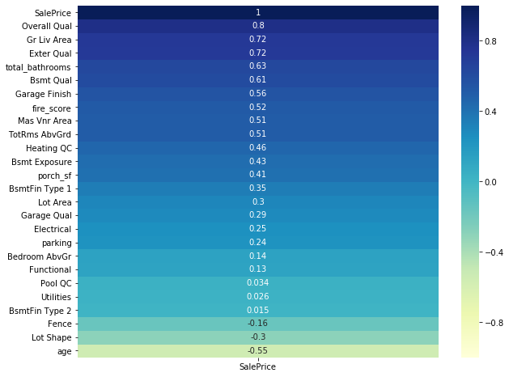

```python
# Explore correlation to target:
fig, ax = plt.subplots(figsize=(10,8))
sns.heatmap(df[features_target].corr()[['SalePrice']].sort_values('SalePrice'),
            vmax=1, vmin=-1, cmap='YlGnBu', annot=True, ax=ax);
ax.invert_yaxis()
```

```python
features = [col for col in features if col not in ('Overall Qual','Gr Liv Area', 'Exter Qual')]
```

## High correlation with target:

Overall, the correlation with target is still acceptable as none of them are >0.9.

```python
# Explore multi-collinearity:
corr = df[features].corr().abs()
unstack_corr = corr.unstack()
corr_sort = unstack_corr.sort_values(ascending = False)

print(corr_sort[20:30])
```

```
Pool QC          Pool QC            1.000000
porch_sf         porch_sf           1.000000
TotRms AbvGrd    Bedroom AbvGr      0.679696
Bedroom AbvGr    TotRms AbvGrd      0.679696
age              Heating QC         0.546850
Heating QC       age                0.546850
Bsmt Qual        age                0.525816
age              Bsmt Qual          0.525816
Bsmt Qual        total_bathrooms    0.493552
total_bathrooms  Bsmt Qual          0.493552
dtype: float64
```

## High correlation with each other:

The general correlation between each feature seems acceptable as they are less than 0.8.

```python
# Define the feature
X = df[features]
```

```python
# Create dummies for nominal features
X = pd.get_dummies(X, drop_first = True)
```

```python
# Important to split out the train and test set here, and only use the train set for modeling.
# Add back the sale price column to the polynomial feature dataframe
X = pd.concat([X,df['SalePrice']],axis = 1)
# Add back the ID column for test submission at the end
X = pd.concat([X,df['Id']],axis = 1)
```

```python
# split out the test and the train set manually
test = X[X['SalePrice'].isnull()]
X = X[X['SalePrice'].notnull()]
```

```python
# Separate out the target train and test sets
y = X['SalePrice']
# remove the target column in train set
X.drop(columns='SalePrice',inplace = True)
```

## Train test split, standardizing and modeling with Linear regression, Lasso and Ridge

```python
# Train test split
X_train, X_test, y_train, y_test = train_test_split(X, y, test_size =0.2, random_state=42)
```

## Standardizing

```python
# Standardizing
stdsc = StandardScaler()
stdsc.fit(X_train)
X_train = stdsc.transform(X_train)
X_test = stdsc.transform(X_test)
```

## Linear Regression

```python
# Assume linear regression as target is continuous variable
linreg = LinearRegression()
linreg.fit(X_train,y_train)
```

```
LinearRegression(copy_X=True, fit_intercept=True, n_jobs=None, normalize=False)
```

```python
# Linear regression metrics
print("LR cross_val_score", cross_val_score(linreg, X_train, y_train, cv=5).mean())
print('LR train r2 =', linreg.score(X_train, y_train))
print('LR test r2 =', linreg.score(X_test, y_test))
mse = mean_squared_error(y_test, linreg.predict(X_test))
print('LR MSE =', mse)
```

```
LR cross_val_score -6.7803803169653025e+22
LR train r2 = 0.8522624404547277
LR test r2 = -2.585174950869936e+24
LR MSE = 1.5420543274352975e+34
```

## LassoCV model

```python
lasso = LassoCV(n_alphas=2000,cv=5,n_jobs=-1)
lasso.fit(X_train,y_train)
```

```
LassoCV(alphas=None, copy_X=True, cv=5, eps=0.001, fit_intercept=True,
        max_iter=1000, n_alphas=2000, n_jobs=-1, normalize=False,
        positive=False, precompute='auto', random_state=None,
        selection='cyclic', tol=0.0001, verbose=False)
```

```python
# Lasso metrics
print('Lasso train r2 =', lasso.score(X_train, y_train))
print('Lasso test r2 =', lasso.score(X_test, y_test))
mse = mean_squared_error(y_test, lasso.predict(X_test))
print('Lasso MSE =', mse)
```

```
Lasso train r2 = 0.8506755422993247
Lasso test r2 = 0.8395398948925361
Lasso MSE = 957142956.1408296
```

## RidgeCV model

```python
ridge = RidgeCV(alphas=np.linspace(.01, 100, 2000))
ridge.fit(X_train,y_train)
```

```
RidgeCV(alphas=array([1.0000000e-02, 6.0020010e-02, 1.1004002e-01, ..., 9.9899960e+01,
       9.9949980e+01, 1.0000000e+02]),
        cv=None, fit_intercept=True, gcv_mode=None, normalize=False,
        scoring=None, store_cv_values=False)
```

```python
print('Ridge train r2 =', ridge.score(X_train, y_train))
print('Ridge test r2 =', ridge.score(X_test, y_test))
mse = mean_squared_error(y_test, ridge.predict(X_test))
print('Ridge MSE =', mse)
```

```
Ridge train r2 = 0.8517864007040881
Ridge test r2 = 0.8385818516025021
Ridge MSE = 962857674.9871116
```

## Inferential Visualizations and business recommendations

```python
coef = pd.Series(lasso.coef_, index = (X.columns))
```

[figure not shown]

```python
# Positively impacting features sorted
imp_coef = coef.sort_values().tail(15)
imp_coef.plot(kind = "barh")
plt.title("Feature importance using Lasso Model")
```

Looking at the coefficients of the features in the LassoCV model, it is not surprising to see that the general living area would affect the sale price of the Ames house. This is also relavant to the number of total bathrooms both basement and above ground. Total number of rooms and facilities correlate with the overall square feet of the house and thus the larger the square feet, the more expensive the house would be. There is however a strong point for houses built in certain neighbourhoods, for example North Ridge Heights and also Stone Brooks. We do see from our previous plot in EDA that by neighbourhoor, these 2 neighbourhoods are actually the highest in median sale price with the highest price variance.

Interestingly, the MS SubClass 20 is a strong positive predictor of sale price too. 1-Storey classes are popular and might be the reason why house-buyers might purchase such houses as compared to 1.5 storey or 2 storey houses. Purchasing a house within they buyer's financial means is more important than purchasing an expensive house that might consider too extravagant.

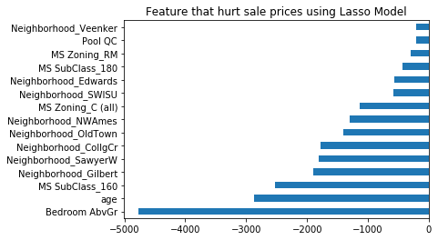

```python
# Negatively impacting features sorted
neg_coef = coef.sort_values().head(15)
neg_coef.plot(kind = "barh")
plt.title("Feature that hurt sale prices using Lasso Model")
```

# Recommendations and business inferences

Perhaps, to further improve the model, we could also look at interaction between lot shape and neighbourhood. This might be interesting because houses build around expensive neighbourhoods can sometimes be more irregular than houses built on flat land. We see houses built on hills or ridges have to follow the slope contours to provide strong foundation for the house. This lot shape and neighbourhood interaction might prove to complement or contradict the current direction of lot shape feature on sale price.

```python
# Selecting only top 10 features for re-modelling
feat_imp = abs(coef).sort_values(ascending = False).head(12).keys()
```

```python
X = X[feat_imp]
test_submission = test[feat_imp]
```

```python
print('Ridge train r2 =', ridge.score(X_train, y_train))
print('Ridge test r2 =', ridge.score(X_test, y_test))
mse = mean_squared_error(y_test, ridge.predict(X_test))
print('Ridge MSE =', np.sqrt(mse))
```

[output not shown]

## Submission of scores

```python
# Get predicted scores from our model above
predict = ridge.predict(test_submission_sc)
submission = pd.DataFrame({
    'Id': test['Id'],
    'SalePrice':predict
})
```

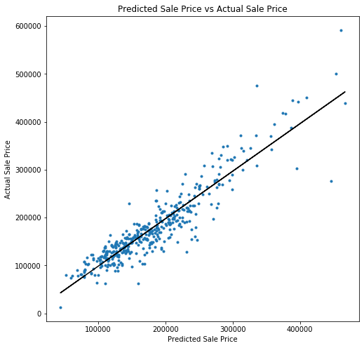

```python
#plt.scatter(x=lasso_overfit_preds, y=y_test, c='r')
plt.figure(figsize=(8,8))
m,b = np.polyfit(x=ridge.predict(X_test), y=y_test, deg=1)
plt.plot(ridge.predict(X_test), y_test, '.')
plt.plot(ridge.predict(X_test), b + m * ridge.predict(X_test), '-', color='k')
frame1 = plt.gca()
plt.xlabel('Predicted Sale Price')
plt.ylabel('Actual Sale Price')
plt.title('Predicted Sale Price vs Actual Sale Price')
plt.show()
```